# Youth Report: Coding & Visualizations Guidelines

This document contains all coding & visualization guidelines. There are implementation example at every step.

## Checklist

After reading through the document, refer to this checklist. Run each of your visualization through this and make sure everything is followed.

1. Folder Structure
2. Data Import
3. Comments
4. Code Sections
5. Select Top ~5 Categories
6. Format Category Names
7. Order Categories
8. Format X & Y Labels
9. Flip Coordinates
10. Color Scheme (Most Important!!)
11. Add & Format Data Labels
12. Visibility of Labels (Required sometimes)
13. Format Legend
14. Theme Settings
15. Save Transparent Image
16. Consider Proper Relevance
17. Figure Numbering & Title
18. Note Explaining the Figure (Rarely required)
19. Non Visualization Code
20. Tables

## Prerequisites

Just some things to make the rest of the code work. you can ignore this section

First, importing the tidyverse library

```r
library(tidyverse)
```

Also creating a mock data table to use in examples later (No need to understand this code)

```r
set.seed(26)
size = 500
mock_data <- tibble(
  id = 1:size,
  x_val = sample(c("x1", "x2", "x3", "x4"), size, replace = TRUE),
  two_types = sample(c("Type 1", "Type 2"), size, replace = TRUE),
  three_types = sample(c("Type 1", "Type 2", "Type 3"), size, replace = TRUE),
  four_types = sample(c("Type 1", "Type 2", "Type 3", "Type 4"), size, replace = TRUE),
  five_types = sample(c("Type 1", "Type 2", "Type 3", "Type 4", "Type 5"), size, replace = TRUE)
)
mock_data
```

```
# A tibble: 500 × 6
      id x_val two_types three_types four_types five_types
   <int> <chr> <chr>     <chr>       <chr>      <chr>
 1     1 x4    Type 2    Type 3      Type 2     Type 2
 2     2 x4    Type 1    Type 2      Type 3     Type 4
 3     3 x3    Type 2    Type 3      Type 2     Type 1
 4     4 x4    Type 2    Type 1      Type 1     Type 5
 5     5 x4    Type 1    Type 1      Type 1     Type 4
 6     6 x3    Type 2    Type 3      Type 2     Type 4
 7     7 x3    Type 1    Type 2      Type 4     Type 1
 8     8 x1    Type 1    Type 3      Type 4     Type 2
 9     9 x3    Type 1    Type 1      Type 1     Type 2
10    10 x2    Type 1    Type 3      Type 4     Type 5
# ℹ 490 more rows
```

## 1. Folder Structure

There are 3 data sets we are using: `data_general.csv`, `data_identity.csv`, `data_marriage.csv`. All of these should be stored with the exact name inside a folder names `data` in your working directory. Each findings group should have all their code in single R file.

## 2. Data Import

If you have followed the previous rule, below is how you will be importing the data. Use the same variable names to store the data as shown below, so that there is some basic similarity in our scripts.

```r
data_general <- read_csv("data/data_general.csv")
data_identity <- read_csv("data/data_identity.csv")
data_marriage <- read_csv("data/data_marriage.csv")
```

## 3. Comments

Please make sure your code is commented in detail. This will make it easy for someone else who will look at your code and also if you look at your own code after a long time

## 4. Code Sections

Since there is a lot of code, adding sections in your R Script spares a lot of headache to find code for each plot. This is easy to implement in RStudio: press `Ctrl` + `Shift` + `R` on Windows or `Cmd` + `Shift` + `R` on Mac. A dialogue box will appear, in which you will add the section title and press `OK`. The section title will appear in a line.

You can add extra `#` in that line to convert into sub headings

You can navigate through your document with these headings using this button on the bottom left of your code pane:

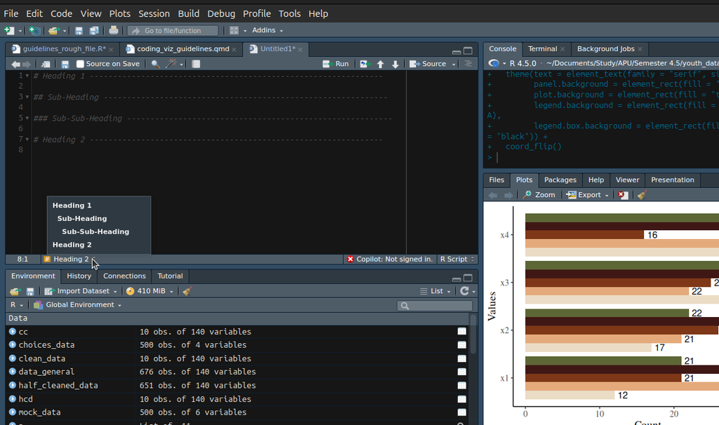

Navigating Rstudio

### Example

The above was obtained from:

```r
# Heading 1 ---------------------------------------------------------------

## Sub-Heading -------------------------------------------------------------

### Sub-Sub-Heading ---------------------------------------------------------

# Heading 2 ---------------------------------------------------------------
```

## 5. Select Top ~5 Categories

Too many categories in graph cause too much clutter. Select few of them. 5 is generally a good number, but you can have a little more if you feel necessary.

If you are selecting top few categories, you can do that using `slice_max(<column-with-values>, n = <how-many-values>)`

### Example

I am creating a graph showing the percentage of people interested to learn specific vocational skills. In last line, I select 5 skills with highest percentage of people interested:

```r
num_interested <- # Number of people interested in skill development programs
  data_general |>
  filter(interest_skill_program == "yes") |>
  nrow()

data_general |>
  filter(interest_skill_program == "yes") |> # take only interested people
  select(choice_skill_program) |>  # select relevant row
  separate_rows(choice_skill_program, sep = " ") |> # separate rows as 1 person could have multiple interests

  count(choice_skill_program) |> # count number of those interested in each program
  mutate(percentage = (n / num_interested) * 100) |>  # find percentage out of those interestes
  filter(!is.na(choice_skill_program)) |>  # remove NA values
  slice_max(percentage, n = 5)  # slice top 5 skills with highest interest
```

```
# A tibble: 5 × 3
  choice_skill_program     n percentage
  <chr>                <int>      <dbl>
1 computer_skill         239       48.0
2 beautician             146       29.3
3 sports                 140       28.1
4 english                135       27.1
5 tailoring              129       25.9
```

**Note**

This pipe can be continued into a `ggplot()` function to create a graph. I will show how to do that later.

## 6. Format Category Names

All variables in the data set are stored in snake case, `which_looks_like_this`. This is because it is easy to code when things are in this format. However, it is also not pleasant to look at.

So we have to manually change each of the category we are showing in our graph. This shouldn’t be hard if you followed the previous rule and selected top 5 things. You can rename the categories using a `case_when()` inside the `mutate()` function (see example)

**Note**

`case_when()` is very similar to `ifelse()`. Just that it makes the job much easier when we have multiple cases.

### Example

Using the previous example, I got to know what the top 5 interests are. Repeating that here.

**Click to see code**

```r
num_interested <- # Number of people interested in skill development programs
  data_general |>
  filter(interest_skill_program == "yes") |>
  nrow()

data_general |>
  filter(interest_skill_program == "yes") |> # take only interested people
  select(choice_skill_program) |>  # select relevant row
  separate_rows(choice_skill_program, sep = " ") |> # separate rows as 1 person could have multiple interests

  count(choice_skill_program) |> # count number of those interested in each program
  mutate(percentage = (n / num_interested) * 100) |>  # find percentage out of those interestes
  filter(!is.na(choice_skill_program)) |>  # remove NA values
  slice_max(percentage, n = 5)  # slice top 5 skills with highest interest
```

```
# A tibble: 5 × 3
  choice_skill_program     n percentage
  <chr>                <int>      <dbl>
1 computer_skill         239       48.0
2 beautician             146       29.3
3 sports                 140       28.1
4 english                135       27.1
5 tailoring              129       25.9
```

Now we will change each of these manually using `case_when()` inside a `mutate()`. It is implemented between lines `11` & `19`. Then we will plot the graph.

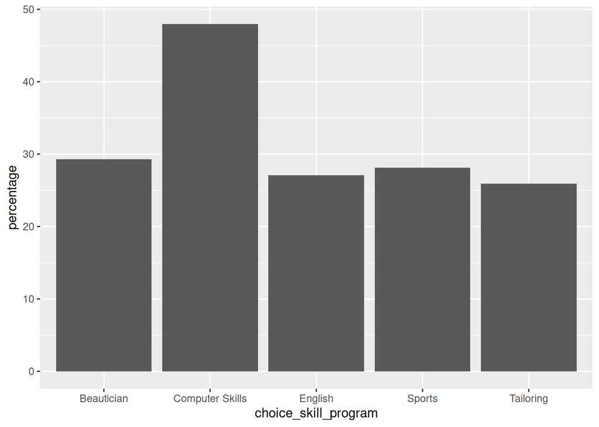

```r
data_general |>
  filter(interest_skill_program == "yes") |> # take only interested people
  select(choice_skill_program) |>  # select relevant row
  separate_rows(choice_skill_program, sep = " ") |> # separate rows as 1 person could have multiple interests

  count(choice_skill_program) |> # count number of those interested in each program
  mutate(percentage = (n / num_interested) * 100) |>  # find percentage out of those interestes
  filter(!is.na(choice_skill_program)) |>  # remove NA values
  slice_max(percentage, n = 5) |> # slice top 5 skills with highest interest

  mutate(choice_skill_program = case_when( # Capitalize and space top 5 skills
    choice_skill_program == "computer_skill" ~ "Computer Skills",
    choice_skill_program == "beautician" ~ "Beautician",
    choice_skill_program == "sports" ~ "Sports",
    choice_skill_program == "english" ~ "English",
    choice_skill_program == "tailoring" ~ "Tailoring",
    .default = choice_skill_program # if none of the above match, keep as it is
    )
  ) |>

  ggplot(
    aes(
      x = choice_skill_program,
      y = percentage
      )) +
  geom_col()
```

Here you can also see how we continue the pipe into the `ggplot()` function to plot our modified data.

## 7. Order Categories

It is usually a good idea to order the categories as per their values. This can be done using `fct_reorder()` when setting the `aes()` of your `ggplot()` function

**Note**

Sometimes ordering according to numbers/percentages is not the best way to do things. Say, you are plotting the education level of our demographics. In this case, ordering the categories from lowest to highest education level is a better way to do it rather than ordering them according to which level has the highest number of people

### Example

Reordering the categories in the previous example based on percentage of people interested. This is implemented in line `23` below.

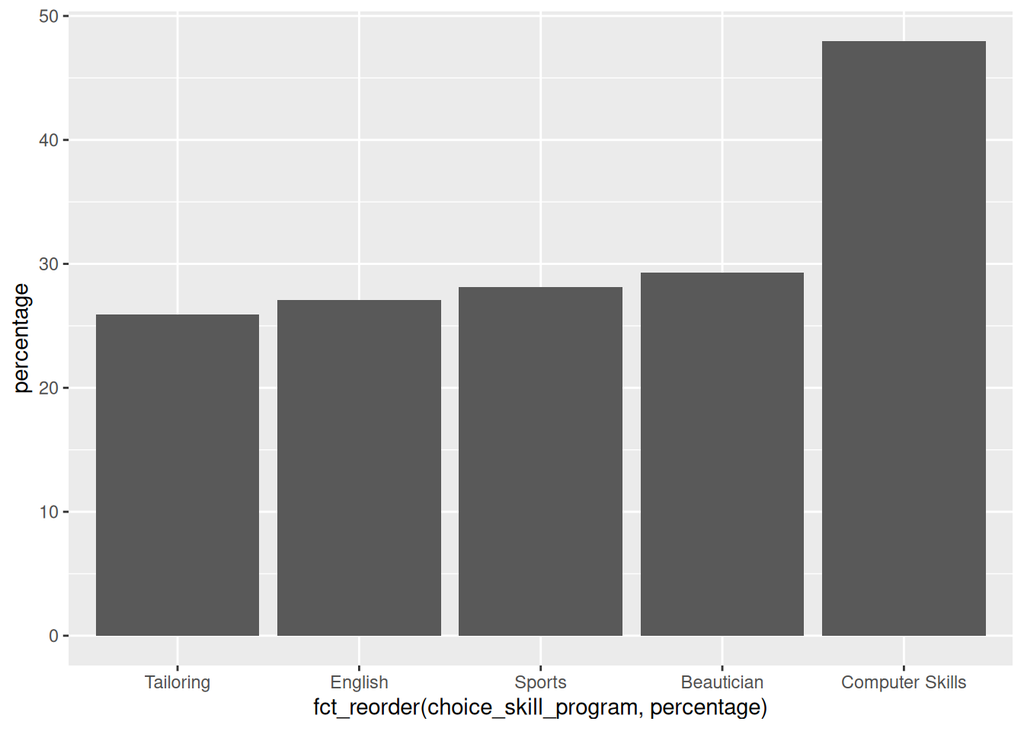

```r
data_general |>
  filter(interest_skill_program == "yes") |> # take only interested people
  select(choice_skill_program) |>  # select relevant row
  separate_rows(choice_skill_program, sep = " ") |> # separate rows as 1 person could have multiple interests

  count(choice_skill_program) |> # count number of those interested in each program
  mutate(percentage = (n / num_interested) * 100) |>  # find percentage out of those interestes
  filter(!is.na(choice_skill_program)) |>  # remove NA values
  slice_max(percentage, n = 5) |> # slice top 5 skills with highest interest

  mutate(choice_skill_program = case_when( # Capitalize and space top 5 skills
    choice_skill_program == "computer_skill" ~ "Computer Skills",
    choice_skill_program == "beautician" ~ "Beautician",
    choice_skill_program == "sports" ~ "Sports",
    choice_skill_program == "english" ~ "English",
    choice_skill_program == "tailoring" ~ "Tailoring",
    .default = choice_skill_program # if none of the above match, keep as it is
    )
  ) |>

  ggplot(
    aes(
      x = fct_reorder(choice_skill_program, percentage), # order skills as per percentage of interest
      y = percentage
      )) +
  geom_col()
```

## 8. Format X & Y Labels

The labels in the X & Y axis also need to be formatted with proper case and spacing. This can be done by adding `xlab()` and `ylab()` to the plot

### Example

Setting X & Y axis labels in the previous example in line `27` & `28` below.

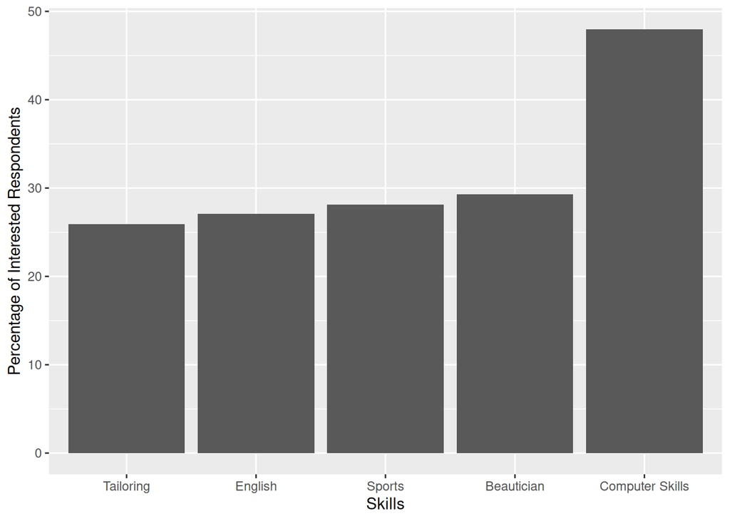

```r
data_general |>
  filter(interest_skill_program == "yes") |> # take only interested people
  select(choice_skill_program) |>  # select relevant row
  separate_rows(choice_skill_program, sep = " ") |> # separate rows as 1 person could have multiple interests

  count(choice_skill_program) |> # count number of those interested in each program
  mutate(percentage = (n / num_interested) * 100) |>  # find percentage out of those interestes
  filter(!is.na(choice_skill_program)) |>  # remove NA values
  slice_max(percentage, n = 5) |> # slice top 5 skills with highest interest

  mutate(choice_skill_program = case_when( # Capitalize and space top 5 skills
    choice_skill_program == "computer_skill" ~ "Computer Skills",
    choice_skill_program == "beautician" ~ "Beautician",
    choice_skill_program == "sports" ~ "Sports",
    choice_skill_program == "english" ~ "English",
    choice_skill_program == "tailoring" ~ "Tailoring",
    .default = choice_skill_program # if none of the above match, keep as it is
    )
  ) |>

  ggplot(
    aes(
      x = fct_reorder(choice_skill_program, percentage), # order skills as per percentage of interest
      y = percentage
      )) +
  geom_col() +
  xlab("Skills") +
  ylab("Percentage of Interested Respondents")
```

## 9. Flip Coordinates

Bar/Column charts should be flipped in general. This especially helps if the category name is long, it sits better in the y-axis. This can be achieved by adding `coord_flip()` to the plot.

### Example

Flipping the previous graph in line `29` below.

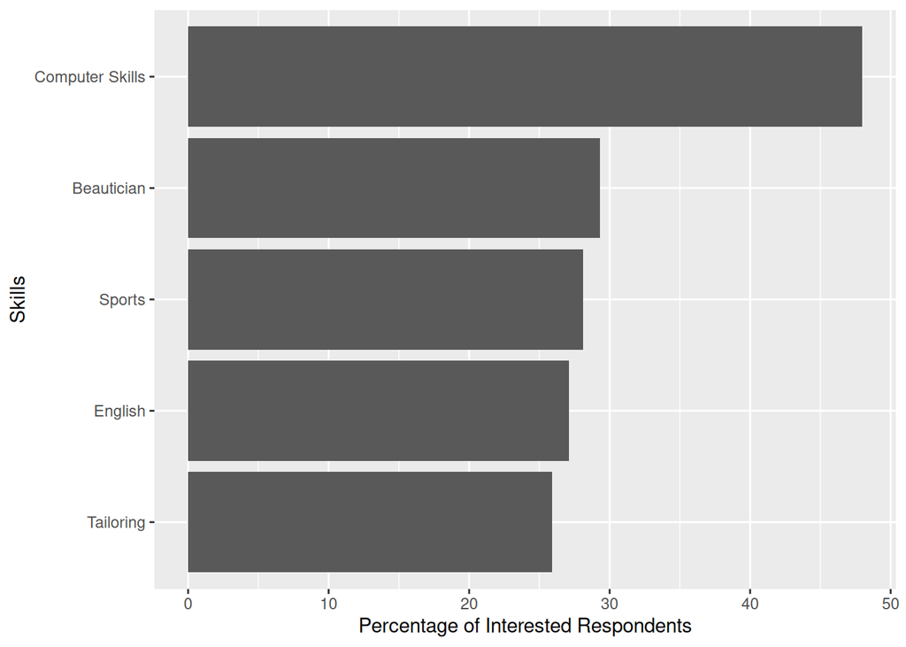

```r
data_general |>
  filter(interest_skill_program == "yes") |> # take only interested people
  select(choice_skill_program) |>  # select relevant row
  separate_rows(choice_skill_program, sep = " ") |> # separate rows as 1 person could have multiple interests

  count(choice_skill_program) |> # count number of those interested in each program
  mutate(percentage = (n / num_interested) * 100) |>  # find percentage out of those interestes
  filter(!is.na(choice_skill_program)) |>  # remove NA values
  slice_max(percentage, n = 5) |> # slice top 5 skills with highest interest

  mutate(choice_skill_program = case_when( # Capitalize and space top 5 skills
    choice_skill_program == "computer_skill" ~ "Computer Skills",
    choice_skill_program == "beautician" ~ "Beautician",
    choice_skill_program == "sports" ~ "Sports",
    choice_skill_program == "english" ~ "English",
    choice_skill_program == "tailoring" ~ "Tailoring",
    .default = choice_skill_program # if none of the above match, keep as it is
    )
  ) |>

  ggplot(
    aes(
      x = fct_reorder(choice_skill_program, percentage), # order skills as per percentage of interest
      y = percentage
      )) +
  geom_col() +
  xlab("Skills") +
  ylab("Percentage of Interested Respondents") +
  coord_flip()
```

## 10. Color Scheme (Most Important!!)

Below you will find the hex-values of colors to be used. It depends on how many colors your graph needs (which depends on the number of stacks your graph will have)

Only 1 stack: `"#7e3717"` OR `"#5d6736"`

2 stacks: `"#7e3717", "#3f1816"` OR `"#ebdcc5", "#5d6736"`

3 stacks: `"#e5aa7b", "#7e3717", "#3f1816"`

4 stacks: `"#e5aa7b", "#7e3717", "#3f1816", "#5d6736"`

5 stacks: `"#ebdcc5", "#e5aa7b", "#7e3717", "#3f1816", "#5d6736"`

Graphs with 1 or 2 colors would be the most common. So we have provided two choices for each of these. You can alternate between them so that the report doesn’t look monotonic.

If your graph has only 1 color, you cans set it using the `fill` parameter. If your graph has multiple colors, you have to add `scale_fill_manual(values = <color_vector>)` with all the colors to the plot.

### Example

#### Single Stack Graph

Using the previous example with both the colors separately. The `fill` parameter has been implemented on line `26` with `"#7e3717"` color.

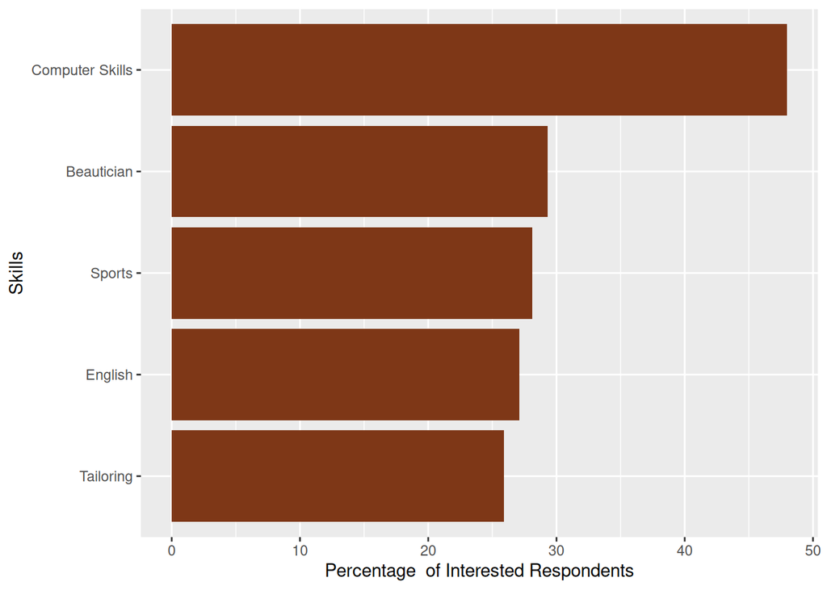

```r
data_general |>
  filter(interest_skill_program == "yes") |> # take only interested people
  select(choice_skill_program) |>  # select relevant row
  separate_rows(choice_skill_program, sep = " ") |> # separate rows as 1 person could have multiple interests

  count(choice_skill_program) |> # count number of those interested in each program
  mutate(percentage = (n / num_interested) * 100) |>  # find percentage out of those interestes
  filter(!is.na(choice_skill_program)) |>  # remove NA values
  slice_max(percentage, n = 5) |> # slice top 5 skills with highest interest

  mutate(choice_skill_program = case_when( # Capitalize and space top 5 skills
    choice_skill_program == "computer_skill" ~ "Computer Skills",
    choice_skill_program == "beautician" ~ "Beautician",
    choice_skill_program == "sports" ~ "Sports",
    choice_skill_program == "english" ~ "English",
    choice_skill_program == "tailoring" ~ "Tailoring",
    .default = choice_skill_program # if none of the above match, keep as it is
    )
  ) |>

  ggplot(
    aes(
      x = fct_reorder(choice_skill_program, percentage), # order skills as per percentage of interest
      y = percentage
      )) +
  geom_col(fill = "#7e3717") +
  xlab("Skills") +
  ylab("Percentage  of Interested Respondents") +
  coord_flip()
```

Similarly, using the `#5d6736` color instead:

**Click to see code**

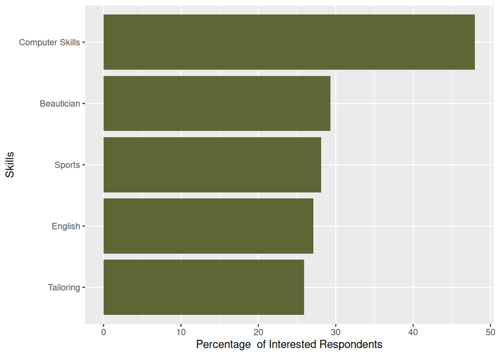

```r
data_general |>
  filter(interest_skill_program == "yes") |> # take only interested people
  select(choice_skill_program) |>  # select relevant row
  separate_rows(choice_skill_program, sep = " ") |> # separate rows as 1 person could have multiple interests

  count(choice_skill_program) |> # count number of those interested in each program
  mutate(percentage = (n / num_interested) * 100) |>  # find percentage out of those interestes
  filter(!is.na(choice_skill_program)) |>  # remove NA values
  slice_max(percentage, n = 5) |> # slice top 5 skills with highest interest

  mutate(choice_skill_program = case_when( # Capitalize and space top 5 skills
    choice_skill_program == "computer_skill" ~ "Computer Skills",
    choice_skill_program == "beautician" ~ "Beautician",
    choice_skill_program == "sports" ~ "Sports",
    choice_skill_program == "english" ~ "English",
    choice_skill_program == "tailoring" ~ "Tailoring",
    .default = choice_skill_program # if none of the above match, keep as it is
    )
  ) |>

  ggplot(
    aes(
      x = fct_reorder(choice_skill_program, percentage), # order skills as per percentage of interest
      y = percentage
      )) +
  geom_col(fill = "#5d6736") +
  xlab("Skills") +
  ylab("Percentage  of Interested Respondents") +
  coord_flip()
```

#### Dual Stack Graph

For this I will use the `mock_data` tibble we created earlier. `scale_fill_manual()` has been implemented on line `4` with the color scheme `"#7e3717", "#3f1816"`.

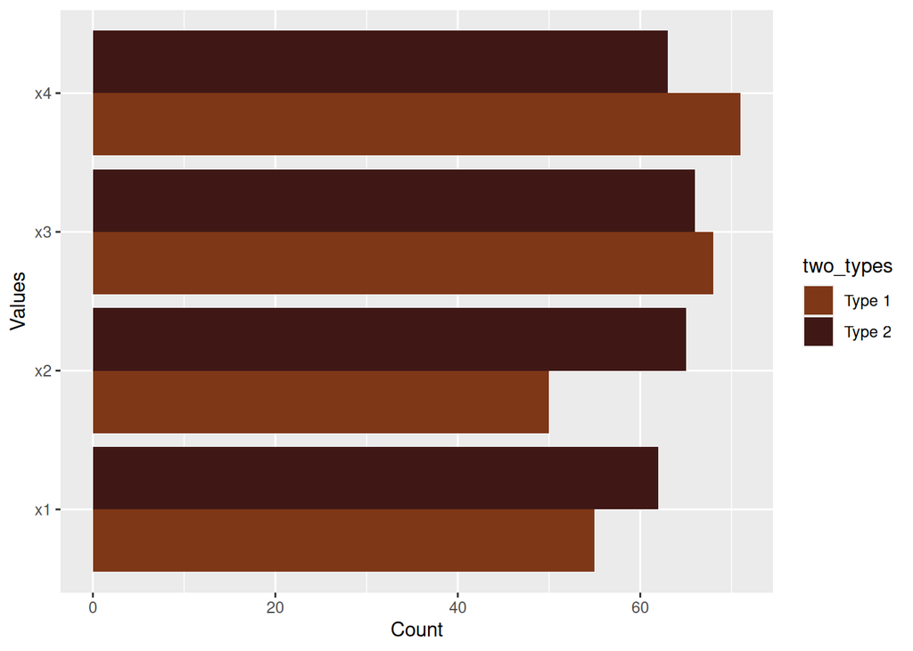

```r
ggplot(mock_data, aes(x = x_val, fill = two_types)) +
  geom_bar(position = "dodge") +
  xlab("Values") + ylab("Count") +
  scale_fill_manual(values = c("#7e3717", "#3f1816")) +
  coord_flip()
```

Similarly, using the other color scheme (`"#ebdcc5", "#5d6736"`) instead:

**Click to see code**

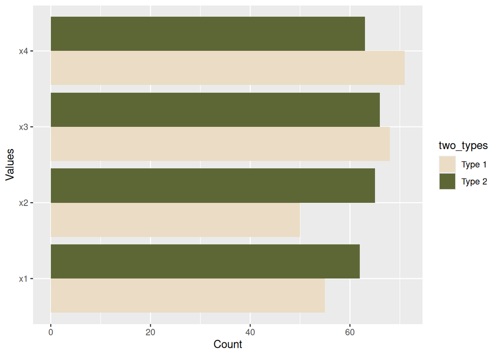

```r
ggplot(mock_data, aes(x = x_val, fill = two_types)) +
  geom_bar(position = "dodge") +
  xlab("Values") + ylab("Count") +
  scale_fill_manual(values = c("#ebdcc5", "#5d6736")) +
  coord_flip()
```

#### >2 Stack Graphs

Doing the same thing with appropriate color scheme for graphs with 3, 4 and 5 stacks.

**Click to see code**

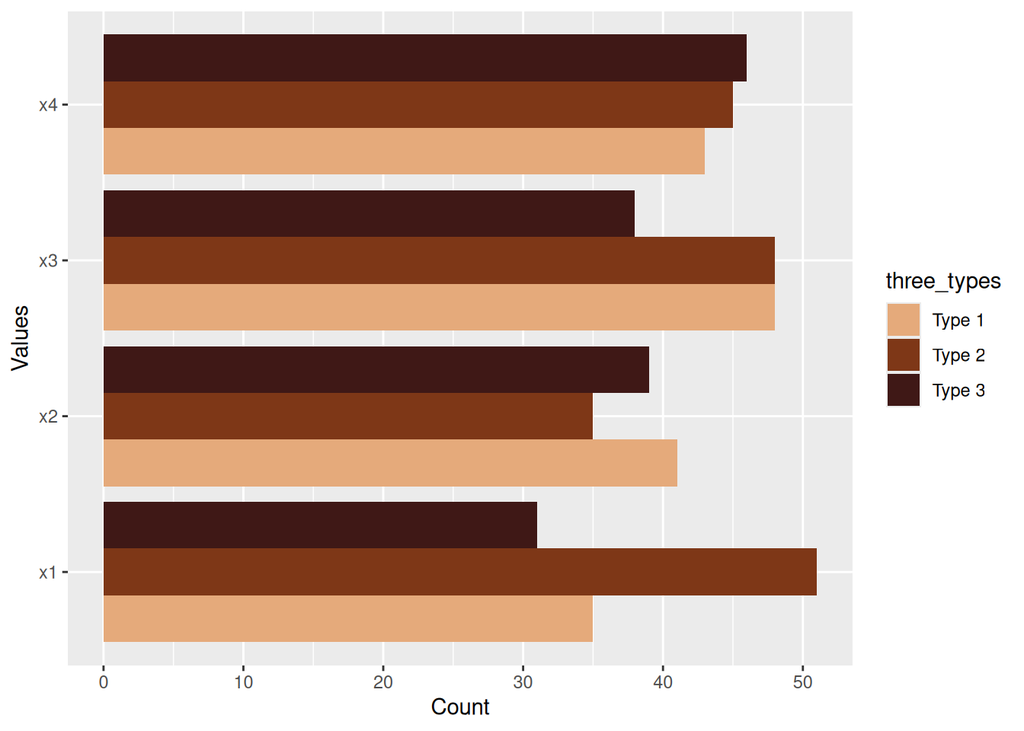

```r
ggplot(mock_data, aes(x = x_val, fill = three_types)) +
  geom_bar(position = "dodge") +
  xlab("Values") + ylab("Count") +
  scale_fill_manual(values = c("#e5aa7b", "#7e3717", "#3f1816")) +
  coord_flip()
```

**Click to see code**

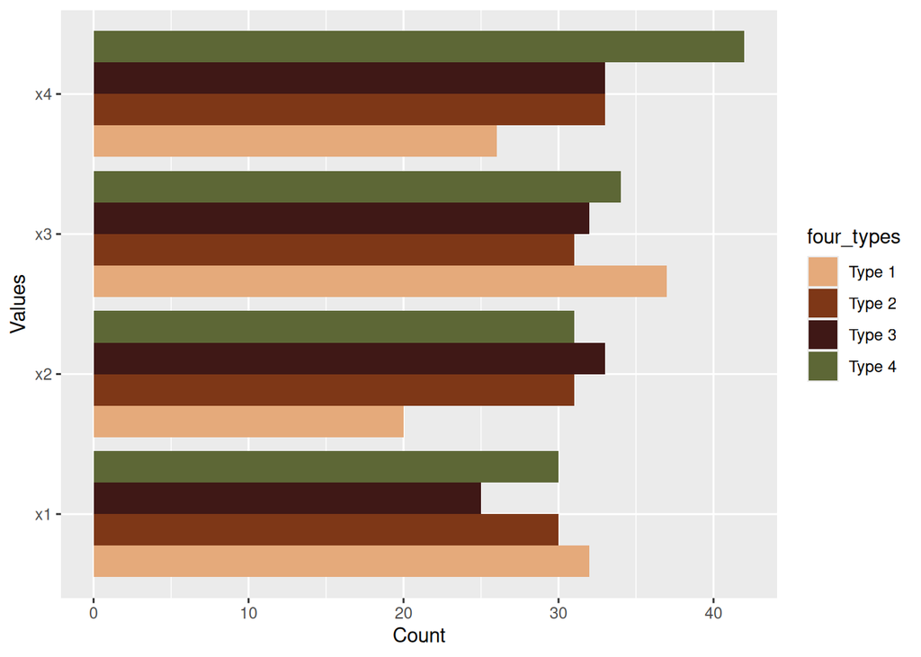

```r
ggplot(mock_data, aes(x = x_val, fill = four_types)) +
  geom_bar(position = "dodge") +
  xlab("Values") + ylab("Count") +
  scale_fill_manual(values = c("#e5aa7b", "#7e3717", "#3f1816", "#5d6736")) +
  coord_flip()
```

**Click to see code**

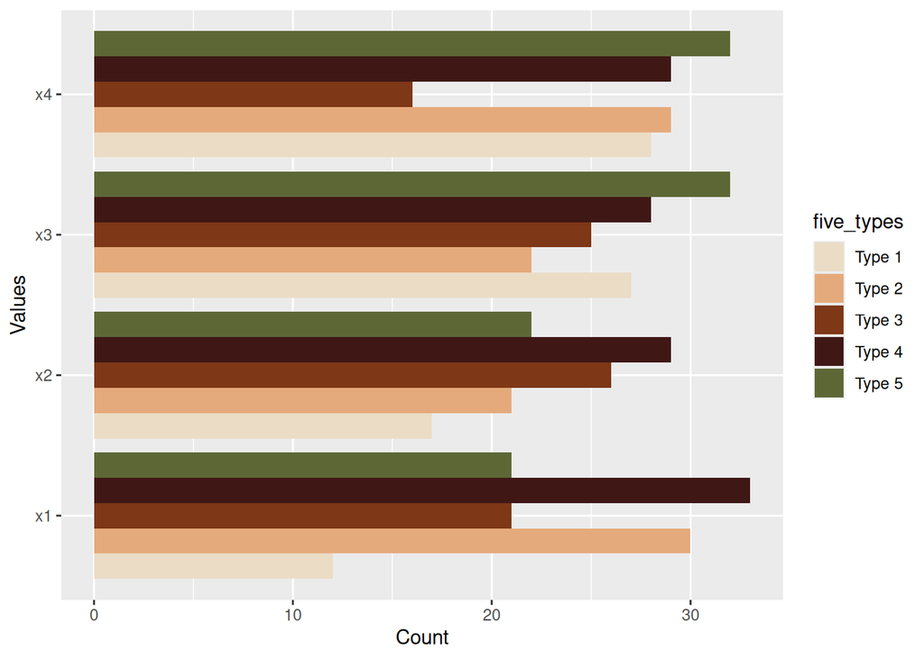

```r
ggplot(mock_data, aes(x = x_val, fill = five_types)) +
  geom_bar(position = "dodge") +
  xlab("Values") + ylab("Count") +
  scale_fill_manual(values = c("#ebdcc5", "#e5aa7b", "#7e3717", "#3f1816", "#5d6736")) +
  coord_flip()
```

## 11. Add & Format Data Labels

You need to add data labels to the graph so that exact values can be shown. Moreover, the values have to be rounded to the nearest whole number.

This section has a mouthful of code, so do see the examples.

If you are using `geom_col()`, this can be done by adding `geom_text(aes(label = round(<y-axis-column>)), hjust = <some-negative-value>)` to the plot.

If you are using `geom_bar()` without a specific y column , you have to add use `geom_text(stat = "count", aes(label = after_stat(count)), hjust = <some-negative-value>)` instead.

**Difference between `geom_col()` and `geom_bar()`**

In `geom_col()` you need to mention both the x & y axis columns in the `aes()`. But in `geom_bar()`, you usually mention only the x axis column in the `aes()`. The y axis in `geom_bar()`by default is the `count` of the categories mentioned in the x axis. (In other words, `geom_bar()` creates a frequency plot by default.)

You can add certain arguments to `geom_bar()` to make it behave like `geom_col()`, but I will not cover that here. In general: Use `geom_col()` if you have columns for both x & y values and use `geom_bar()` if you want the y axis to have a count of x axis values.

In our examples, I have used `geom_col()` for the Vocational Skills, and `geom_bar()` for `mock_data`.

If your graph doesn’t have flipped coordinates, use `vjust` instead of `hjust`. They should have a negative value because we need the labels above the bars.

If your graph has multiple stacks side by side, you have to add a `position = position_dodge(width = <some-value>)` argument to `geom_text()` so that the labels don’t overlap.

Again, this is a little tricky to understand, so don’t worry if you didn’t understand and see the examples.

### Examples

##### `geom_col()`, Single Stack

Using the vocational skills example which uses `geom_col()` with only single stack. Labels have been implemented between lines `29` & `32`.

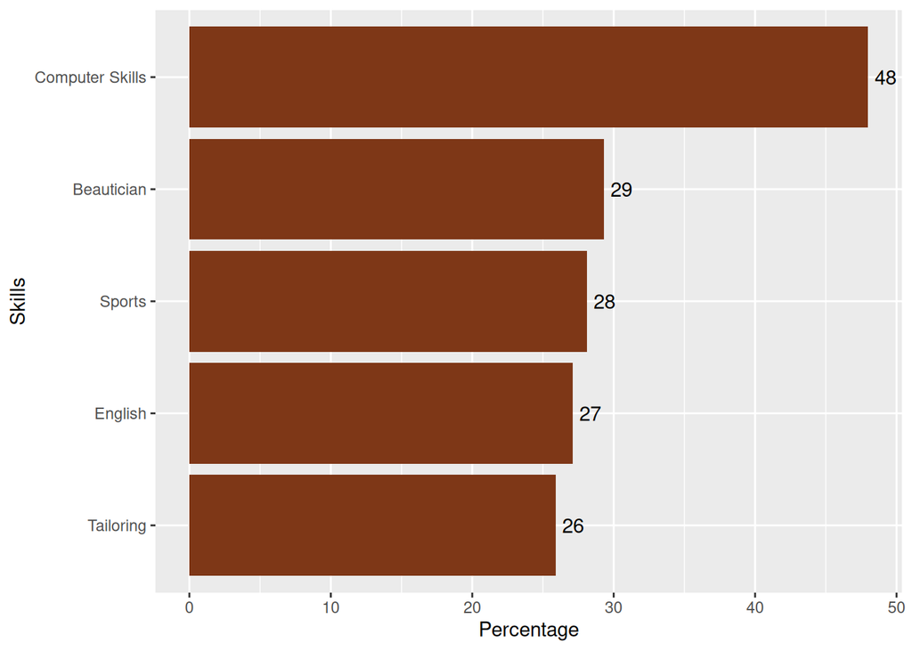

```r
data_general |>
  filter(interest_skill_program == "yes") |> # take only interested people
  select(choice_skill_program) |>  # select relevant row
  separate_rows(choice_skill_program, sep = " ") |> # separate rows as 1 person could have multiple interests

  count(choice_skill_program) |> # count number of those interested in each program
  mutate(percentage = (n / num_interested) * 100) |>  # find percentage out of those interestes
  filter(!is.na(choice_skill_program)) |>  # remove NA values
  slice_max(percentage, n = 5) |> # slice top 5 skills with highest interest

  mutate(choice_skill_program = case_when( # Capitalize and space top 5 skills
    choice_skill_program == "computer_skill" ~ "Computer Skills",
    choice_skill_program == "beautician" ~ "Beautician",
    choice_skill_program == "sports" ~ "Sports",
    choice_skill_program == "english" ~ "English",
    choice_skill_program == "tailoring" ~ "Tailoring",
    .default = choice_skill_program # if none of the above match, keep as it is
    )
  ) |>

  ggplot(
    aes(
      x = fct_reorder(choice_skill_program, percentage), # order skills as per percentage of interest
      y = percentage
      )) +
  geom_col(fill = "#7e3717") +
  xlab("Skills") +
  ylab("Percentage") +
  geom_text(
    aes(label = round(percentage)), #use percentage as labels
    hjust = -0.3 # adjust horizontal position of labels
    ) +
  coord_flip()
```

#### `geom_bar()`, Single Stack

Using the `mock_data` example with a single stack. Labels have been implemented between lines `5` & `9`.

```r
ggplot(mock_data, aes(x = x_val)) +
  geom_bar(fill = "#5d6736") +
  xlab("Values") + ylab("Count") +
  ylim(0, 150) +
  geom_text(
    stat = "count",
    aes(label = after_stat(count)),
    hjust = -0.3) +
  coord_flip()
```

[output not shown]

#### `geom_bar()`, Multiple Stack

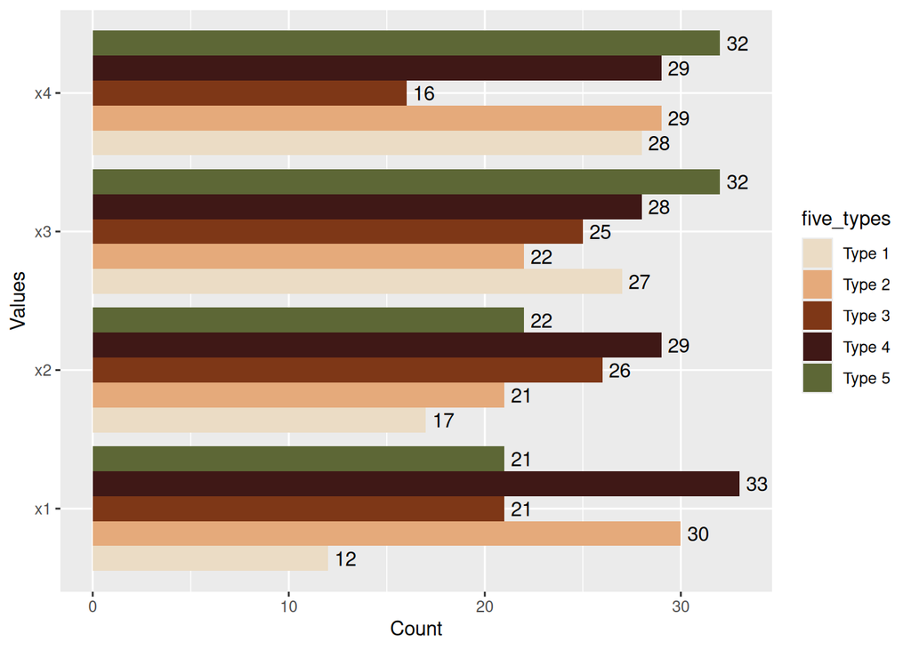

```r
ggplot(mock_data, aes(x = x_val, fill = five_types)) +
  geom_bar(position = "dodge") +
  xlab("Values") + ylab("Count") +
  scale_fill_manual(values = c("#ebdcc5", "#e5aa7b", "#7e3717", "#3f1816", "#5d6736")) +
  geom_text(
    stat = "count",
    aes(label = after_stat(count)),
    position = position_dodge(width = 0.9),
    hjust = -0.3) +
  coord_flip()
```

**Note**

I have not implemented labels in `geom_col()` with multiple stacks. It is very similar to the first example here, except that you have to also add `position = position_dodge(width = <some-value>)` inside the `geom_text()`

## 12. Visibility of Labels (Required sometimes)

Sometimes the label are not visible because they get outside the bounds of the plot. In this case, it can be fixed by adding `ylim(<min-y>, <max-y>)` to the plot

### Example

Notice this graph:

**Click to see code**

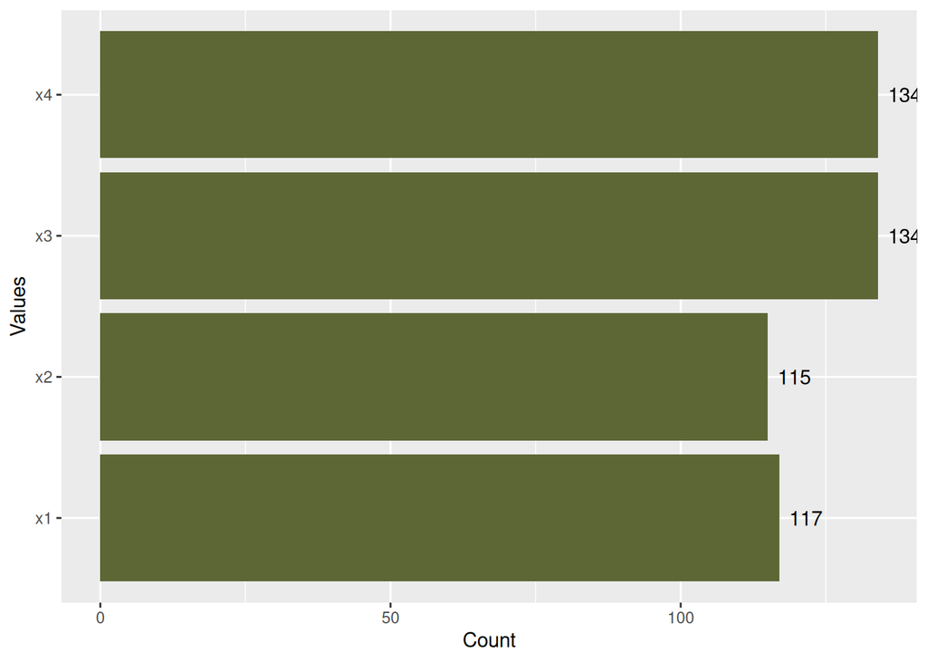

```r
ggplot(mock_data, aes(x = x_val)) +
  geom_bar(fill = "#5d6736") +
  xlab("Values") + ylab("Count") +
  geom_text(
    stat = "count",
    aes(label = after_stat(count)),
    hjust = -0.3) +
  coord_flip()
```

See how the labels for `x3` & `x4` are hidden. To fix that, we will add `ylim()` to the plot, as in line `4`below.

```r
ggplot(mock_data, aes(x = x_val)) +
  geom_bar(fill = "#5d6736") +
  xlab("Values") + ylab("Count") +
  ylim(0, 150) +
  geom_text(
    stat = "count",
    aes(label = after_stat(count)),
    hjust = -0.3) +
  coord_flip()
```

[output not shown]

## 13. Format Legend

Proper casing and spacing also has to be implemented in the legend if you have a multi-stacked graph. The title can be changed using `guides(fill = guide_legend(title = "<legend-tile>"))`.

### Example

Changing the legend title in line `10` below:

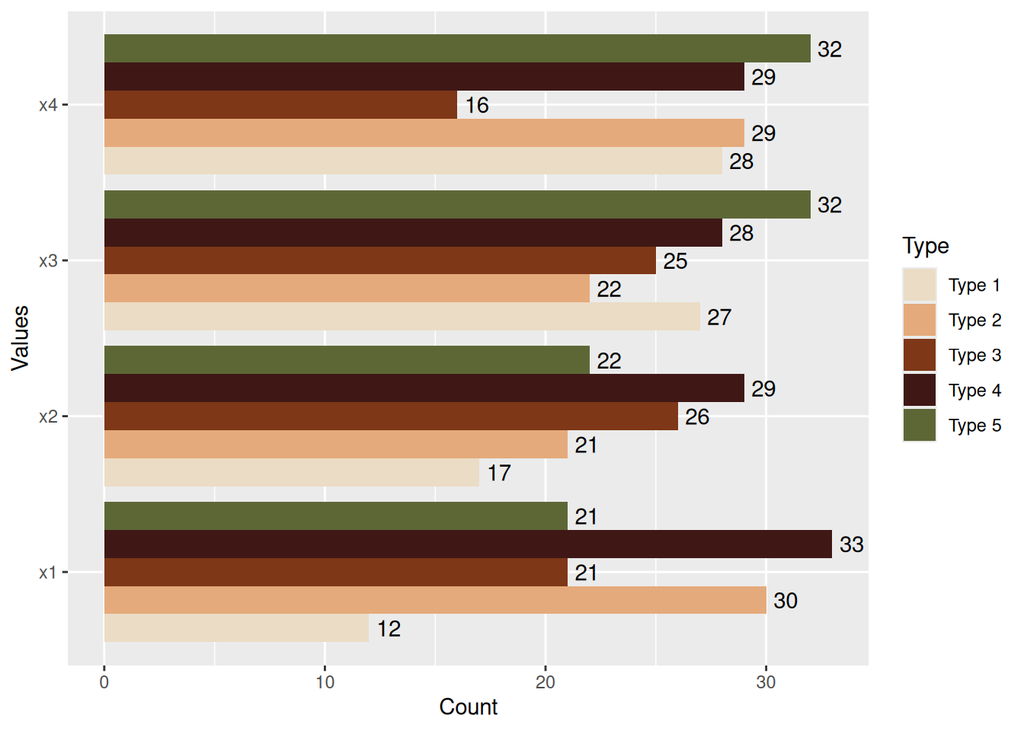

```r
ggplot(mock_data, aes(x = x_val, fill = five_types)) +
  geom_bar(position = "dodge") +
  xlab("Values") + ylab("Count") +
  scale_fill_manual(values = c("#ebdcc5", "#e5aa7b", "#7e3717", "#3f1816", "#5d6736")) +
  geom_text(
    stat = "count",
    aes(label = after_stat(count)),
    position = position_dodge(width = 0.9),
    hjust = -0.3) +
  guides(fill = guide_legend(title = "Type")) +
  coord_flip()
```

## 14. Theme Settings

The following theme features have to be added: `Times New Roman` font, no grid lines, transparent background & box for legend. This can be implemented by adding `theme_classic() + theme(text = element_text(family = "serif"), panel.background = element_rect(fill = "transparent"), plot.background = element_rect(fill = "transparent", color = NA), legend.background = element_rect(fill = "transparent", color = NA), legend.box.background = element_rect(fill = "transparent", color = "black"))` to the plot.

### Example

See lines `11` to `16` below:

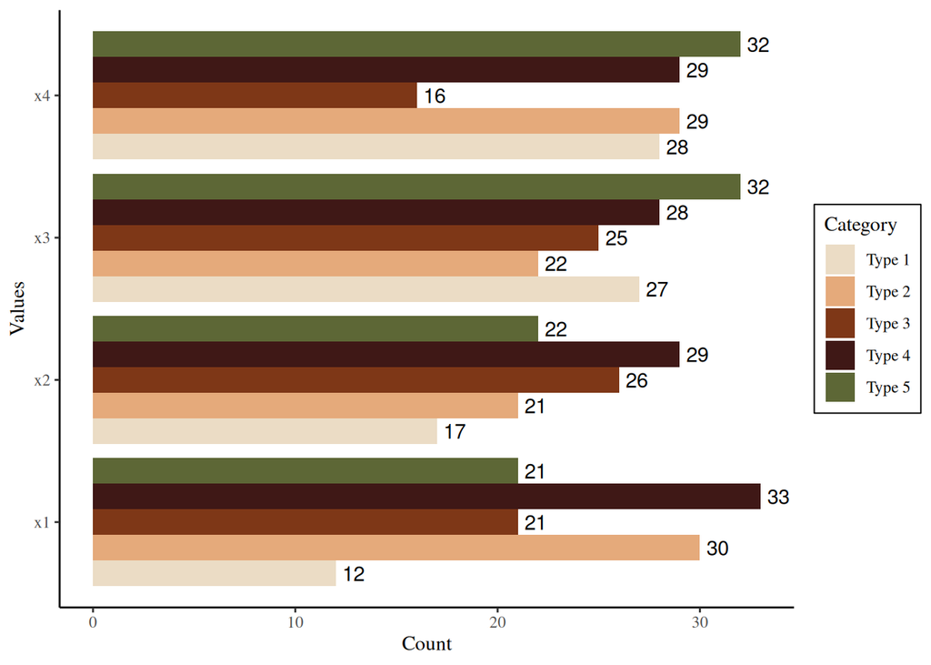

```r
ggplot(mock_data, aes(x = x_val, fill = five_types)) +
  geom_bar(position = "dodge") +
  xlab("Values") + ylab("Count") +
  scale_fill_manual(values = c("#ebdcc5", "#e5aa7b", "#7e3717", "#3f1816", "#5d6736")) +
  geom_text(
    stat = "count",
    aes(label = after_stat(count)),
    position = position_dodge(width = 0.9),
    hjust = -0.3) +
  guides(fill = guide_legend(title = "Category")) +
  theme_classic() +
  theme(text = element_text(family = "serif"),
        panel.background = element_rect(fill = "transparent"),
        plot.background = element_rect(fill = "transparent", color = NA),
        legend.background = element_rect(fill = "transparent", color = NA),
        legend.box.background = element_rect(fill = "transparent", color = "black")) +
  coord_flip()
```

## Bonus: Graphs with all features

In all the above examples, I have added the features one by one so that you can see what changes are happening at every step. However, if you want all the the features in one place as a template, see below.

### Vocational Skills

The vocational skills example:

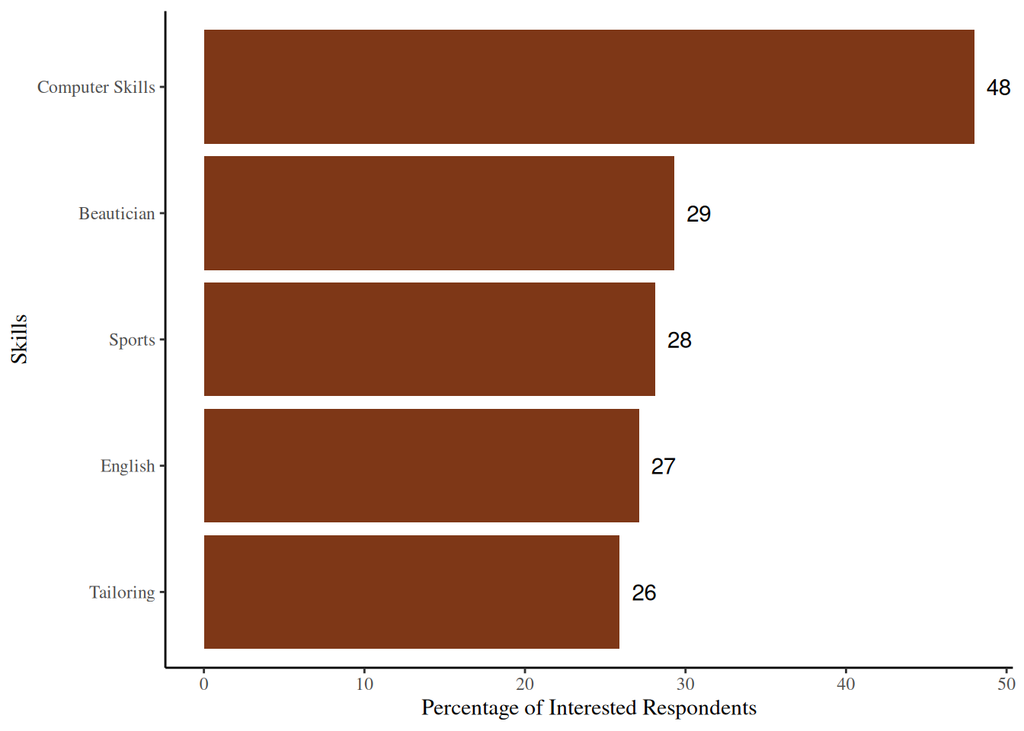

```r
num_interested <- # Number of people interested in skill development programs
  data_general |>
  filter(interest_skill_program == "yes") |>
  nrow()


data_general |>
  filter(interest_skill_program == "yes") |> # take only interested people
  select(choice_skill_program) |>  # select relevant row
  separate_rows(choice_skill_program, sep = " ") |> # separate rows as 1 person could have multiple interests

  count(choice_skill_program) |> # count number of those interested in each program
  mutate(percentage = (n / num_interested) * 100) |>  # find percentage out of those interested
  filter(!is.na(choice_skill_program)) |>  # remove NA values
  slice_max(percentage, n = 5) |> # slice top 5 skills with highest interest

  mutate(choice_skill_program = case_when( # Capitalize and space top 5 skills
    choice_skill_program == "computer_skill" ~ "Computer Skills",
    choice_skill_program == "beautician" ~ "Beautician",
    choice_skill_program == "sports" ~ "Sports",
    choice_skill_program == "english" ~ "English",
    choice_skill_program == "tailoring" ~ "Tailoring",
    .default = choice_skill_program # if none of the above match, keep as it is
    )
  ) |>

  ggplot(
    aes(
      x = fct_reorder(choice_skill_program, percentage), # order skills as per percentage of interest
      y = percentage
      )) +
  geom_col(fill = "#7e3717") +
  xlab("Skills") +
  ylab("Percentage of Interested Respondents") +
  geom_text(
    aes(label = round(percentage)), #use percentage as labels
    hjust = -0.5 # adjust horizontal position of labels
    ) +
  guides(fill = guide_legend(title = "Types")) +
  theme_classic() +
  theme(text = element_text(family = "serif"),
        panel.background = element_rect(fill = "transparent"),
        plot.background = element_rect(fill = "transparent", color = NA),
        legend.background = element_rect(fill = "transparent", color = NA),
        legend.box.background = element_rect(fill = "transparent", color = "black")) +
  coord_flip()
```

### `mock_data`

The `mock_data` example with 1 stack & `ylim()`

```r
ggplot(mock_data, aes(x = x_val)) +
  geom_bar(fill = "#5d6736") +
  xlab("Values") + ylab("Count") +
  ylim(0, 150) +
  geom_text(
    stat = "count",
    aes(label = after_stat(count)),
    hjust = -0.3) +
  coord_flip()
```

[output not shown]

The `mock_data` example with 5 stacks:

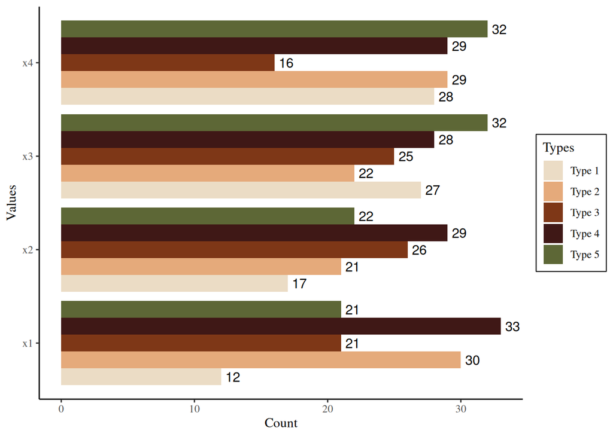

```r
ggplot(mock_data, aes(x = x_val, fill = five_types)) +
  geom_bar(position = "dodge") +
  xlab("Values") + ylab("Count") +
  scale_fill_manual(values = c("#ebdcc5", "#e5aa7b", "#7e3717", "#3f1816", "#5d6736")) +
  geom_text(
    stat = "count",
    aes(label = after_stat(count)),
    position = position_dodge(width = 0.9),
    hjust = -0.3) +
  guides(fill = guide_legend(title = "Types")) +
  theme_classic() +
  theme(text = element_text(family = "serif"),
        panel.background = element_rect(fill = "transparent"),
        plot.background = element_rect(fill = "transparent", color = NA),
        legend.background = element_rect(fill = "transparent", color = NA),
        legend.box.background = element_rect(fill = "transparent", color = "black")) +
  coord_flip()
```

## 15. Save Transparent Image

The images have to be downloaded preserving the transparency and with a 6:4 ratio. To do this, you have to assign a name to the plot. Then run `ggsave("<filename>.png", plot = <assigned-name> , bg = "transparent", width = 6, height = 4, units = "in")`

**Label Visibility in Saved Plots**

Sometimes, the labels appear properly in RStudio but get hidden when downloaded as image. In this case, add `ylim()` as instructed in 12. Visibility of Labels

### Example

Saving the `mock_data` plot in the last line:

```r
ggplot(mock_data, aes(x = x_val, fill = five_types)) +
  geom_bar(position = "dodge") +
  xlab("Values") + ylab("Count") +
  scale_fill_manual(values = c("#ebdcc5", "#e5aa7b", "#7e3717", "#3f1816", "#5d6736")) +
  geom_text(
    stat = "count",
    aes(label = after_stat(count)),
    position = position_dodge(width = 0.9),
    hjust = -0.3) +
  guides(fill = guide_legend(title = "Types")) +
  theme_classic() +
  theme(text = element_text(family = "serif"),
        panel.background = element_rect(fill = "transparent"),
        plot.background = element_rect(fill = "transparent", color = NA),
        legend.background = element_rect(fill = "transparent", color = NA),
        legend.box.background = element_rect(fill = "transparent", color = "black")) +
  coord_flip() ->  mock_plot

ggsave("mock_plot.png", plot = mock_plot , bg = "transparent", width = 6, height = 4, units = "in")
```

## 16. Consider Proper Relevance

It is a very common pitfall to only consider the variables we are plotting and forget about the previous relevance that were used in creating the form. Avoid this, and apply `filter()` with appropriate relevance when required.

### Example

In the vocational skills examples I used above, I have always considered only the set of respondents who showed interest in learning vocational skills as the denominator. See lines `3` and `8`.

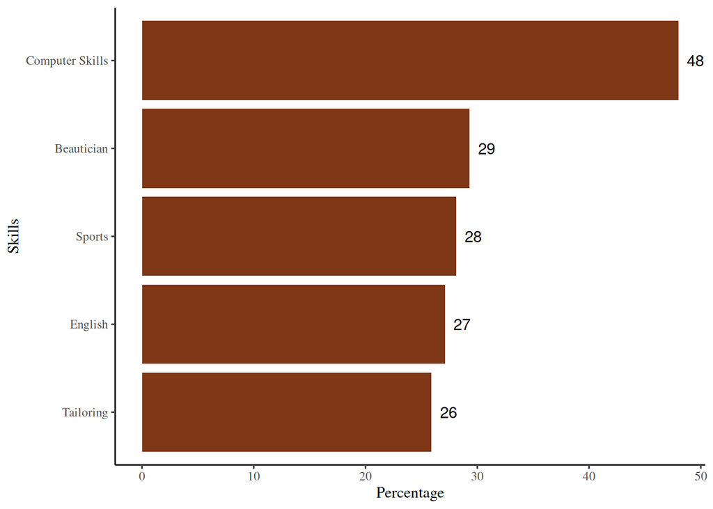

```r
num_interested <- # Number of people interested in skill development programs
  data_general |>
  filter(interest_skill_program == "yes") |>
  nrow()


data_general |>
  filter(interest_skill_program == "yes") |> # take only interested people
  select(choice_skill_program) |>  # select relevant row
  separate_rows(choice_skill_program, sep = " ") |> # separate rows as 1 person could have multiple interests

  count(choice_skill_program) |> # count number of those interested in each program
  mutate(percentage = (n / num_interested) * 100) |>  # find percentage out of those interested
  filter(!is.na(choice_skill_program)) |>  # remove NA values
  slice_max(percentage, n = 5) |> # slice top 5 skills with highest interest

  mutate(choice_skill_program = case_when( # Capitalize and space top 5 skills
    choice_skill_program == "computer_skill" ~ "Computer Skills",
    choice_skill_program == "beautician" ~ "Beautician",
    choice_skill_program == "sports" ~ "Sports",
    choice_skill_program == "english" ~ "English",
    choice_skill_program == "tailoring" ~ "Tailoring",
    .default = choice_skill_program # if none of the above match, keep as it is
    )
  ) |>

  ggplot(
    aes(
      x = fct_reorder(choice_skill_program, percentage), # order skills as per percentage of interest
      y = percentage
      )) +
  geom_col(fill = "#7e3717") +
  xlab("Skills") +
  ylab("Percentage") +
  geom_text(
    aes(label = round(percentage)), #use percentage as labels
    hjust = -0.5 # adjust horizontal position of labels
    ) +
  guides(fill = guide_legend(title = "Types")) +
  theme_classic() +
  theme(text = element_text(family = "serif"),
        panel.background = element_rect(fill = "transparent"),
        plot.background = element_rect(fill = "transparent", color = NA),
        legend.background = element_rect(fill = "transparent", color = NA),
        legend.box.background = element_rect(fill = "transparent", color = "black")) +
  coord_flip()
```

## 17. Figure Numbering & Title

Your figures need to numbered and have a one line title, along with the sample size. This should be written below the image in the google doc (and NOT coded in R). It needs to be in the format `Figure <topic-number>.<figure-number>: <figure-title> (n = <sample-size>)`.

**Don’t code titles**

The titling should NOT be coded using `labs()` into your R script. Write it below the graph on goole docs instead. This will make it easy because to modify things like figure numbering later.

### Example

The vocational skill plot we have been using is, say, the second graph under the “Skill & Vocational Training” topic. This is the fourth topic in the “Findings” Section of our outline. Hence, I will title it as `Figure 4.2: Top 5 Vocational Skills with Highest Interest (n = 498)`.

## 18. Note Explaining the Figure (Rarely Required)

If you have a very complicated visualization, you can provide a short paragraph explaining it. This is usually not required. Avoid it as much as possible by creating visualizations that are easy to understand.

### Example

See Figure 4 on page 28 of the SWAN report

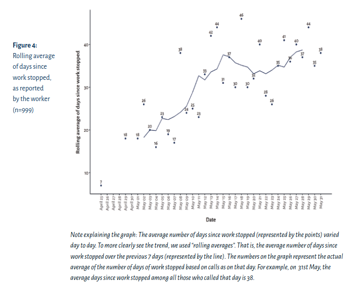

Note Explaining Figure, SWAN Report

## 19. Non Visualization Code

A lot of information in the report need not be presented through graphs & visualizations as they can be written in one line. However, your R script should contain sections with the code you used extract this info.

### Example

In the report, say I mention 74% of our respondents were interested to learn a vocational skill.

```r
# Percentage of Interest in Vocational Skills -----------------------------

num_total <- data_general |> nrow() # Sample size

num_interested <- # No. of respondents interested in vocational skills
  data_general |>
  filter(interest_skill_program == "yes") |>
  nrow()

(num_interested/num_total) * 100 # Calculating percentage
```

```
[1] 73.66864
```

## 20. Tables

When creating tables, do that in google docs instead of putting screenshots of R output.